# Detection of Coffee Adulteration Using Hyperspectral Imaging and Ensemble Machine Learning: Spectra Preprocessed by Standard Normal Variate, Savitzky Golay and Second Derivative (SNV+SG+2nd Der)

Author

Derick Malavi

## Introduction

This project investigates the effectiveness of ensemble learning methods in distinguishing authentic coffee from adulterated samples using the full spectral data derived from hyperspectral imaging (HSI). By utilizing the entire spectral range, the study avoids selective wavelength reduction, instead leveraging the richness of the spectral dataset to ensure comprehensive model inputs.

The ensemble learning framework integrates predictions from diverse base models, including Random Forest (RF), Support Vector Machines (SVM), Artificial Neural Networks (ANN), Linear Discriminant Analysis (LDA), and k-Nearest Neighbors (kNN). Using the stacking approach, the ensemble capitalizes on the strengths of individual algorithms, enhancing robustness and classification accuracy across varying levels of coffee adulteration.

To optimize the quality of the spectral data and minimize noise, preprocessing techniques such as Standard Normal Variate (SNV), Savitzky-Golay (SG) smoothing, and second derivative transformations are applied. These preprocessing steps ensure that the models process cleaner and more informative inputs without selectively narrowing the spectral range.

The ensemble’s performance is rigorously evaluated through 10-fold repeated cross-validation, offering a reliable assessment while reducing the risk of overfitting. This comprehensive approach highlights the model’s generalizability and robustness in identifying adulteration levels across a range of concentrations (e.g., 1%, 5%, 10%, and higher).

The study provides valuable insights into the application of ensemble learning to hyperspectral data analysis, focusing on computational efficiency, sensitivity, and specificity. It underscores the potential of advanced machine learning techniques to leverage full-spectrum data for robust food authenticity and fraud detection.

```r
# Load libraries
warning = FALSE
  suppressWarnings(suppressMessages({
  library(caret)
  library(GA)
  library(ggplot2)
  library(dplyr)
  library(readxl)
  library(readr)
  library(pls)
  library(janitor)
  library(class)
  library(MLmetrics)
  library(MLeval)
  library(themis)
  library(NeuralNetTools)
  library(ROSE)
  library(parallel)
  library(doParallel)
  library(foreach)
  library(pheatmap)
  library(mdatools)
  library(nnet)
  library(DMwR)
  library(e1071)
  library(knitr)
  library(caretEnsemble)
  library(pROC)
  library(gridExtra)
  library(FactoMineR)
  library(doSNOW)
  library(MASS)
  library(Boruta)
  library(ggthemes)
  library(factoextra)
  library(kernlab)}))
```

## Prepare Data

```r
# Load data: snv_sg_2d spectra

hsi_snv_sg_2d <- read.csv("coffee_ground_snv_sg_2d.csv")

# Ensure we have the same number of dimensions and the range of our columns/covariates
dim(hsi_snv_sg_2d)
```

```
[1] 1469  229
```

```r
# Check a few column names
col_check <- colnames(hsi_snv_sg_2d[,c(1:6)])
col_check
```

```
[1] "sample_id"     "binary_class"  "three_class"   "adult_percent"
[5] "cal_val"       "X935.609985"
```

```r
# The spectral values start from column # 6-------> 229

# Convert the class to a factor
hsi_snv_sg_2d$binary_class <- as.factor(hsi_snv_sg_2d$binary_class)
```

## Get the X and y variables

```r
X <- hsi_snv_sg_2d[,c(6:229)]
y <- hsi_snv_sg_2d[,2]

class(y) #Ensure y (target variable) is a factor for classification
```

```
[1] "factor"
```

## Visualize X

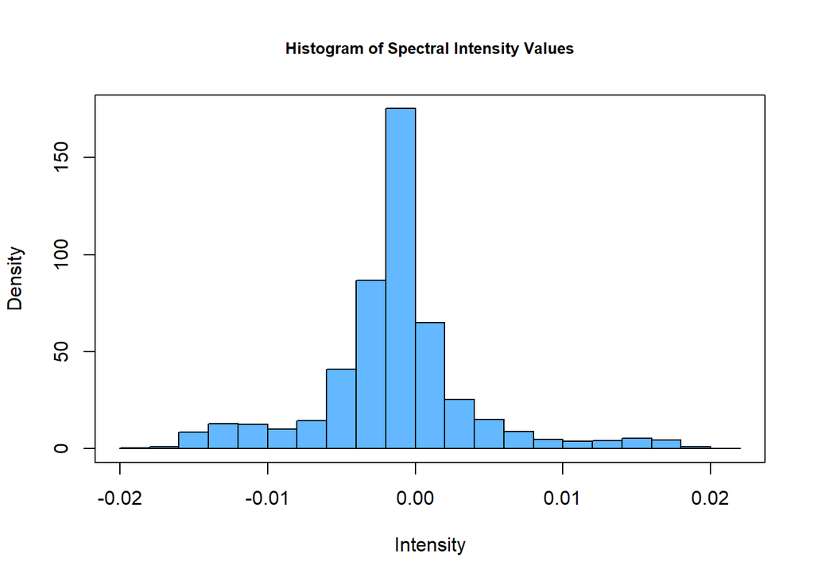

```r
hist(as.matrix(X), col = 'steelblue1', freq = FALSE,
     main = 'Histogram of Spectral Intensity Values', cex.main = 0.8,
     xlab = 'Intensity'); box()
```

## Split the Data (Train_Test Split)

- We want to select features based on training data only to avoid any data leakage that could inflate model performance and make the model less generalizable to unseen data.

```r
# Subset samples for cross-validation and external validation (70/30)
# Record 1 under cal_val variable is for calibration while 2 will be for testing the model

sample<-hsi_snv_sg_2d$cal_val== 1

# Split to train and test sets
X_train <- X[sample,]
X_test <- X[!sample,]
y_train <-y[sample]
y_test <- y[!sample]

# Check length of the subsets for training and validation
dim(X_train)
```

```
[1] 1055  224
```

```r
dim(X_test)
```

```
[1] 414 224
```

```r
length(y_train)
```

```
[1] 1055
```

```r
length(y_test)
```

```
[1] 414
```

```r
# Merge the test and train data
train_data <- data.frame(X_train, binary_class = y_train)
test_data <- data.frame(X_test, binary_class = y_test)

# Check composition of the y variable for both train and test sets
table(train_data$binary_class)
```

```
 adulterated pure_arabica
        1007           48
```

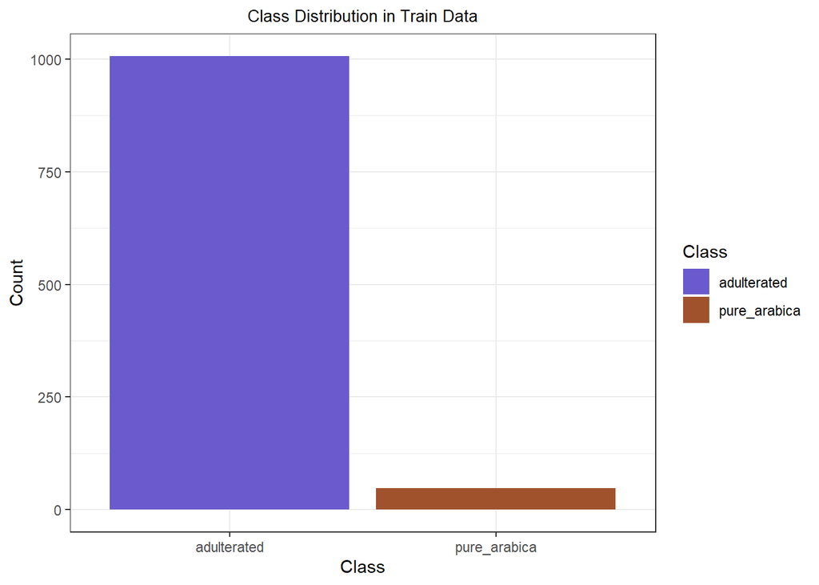

```r
# Create a bar plot for class distribution in train_data
train_data %>%
  count(binary_class) %>%
  ggplot(aes(x = binary_class, y = n, fill = binary_class)) +
  geom_bar(stat = "identity") +
  scale_fill_manual(values = c("slateblue", "sienna")) +  # Specify your custom colors here
  labs(title = "Class Distribution in Train Data",
       x = "Class",
       y = "Count",
       fill = "Class") +  # Ensure legend names are retained
  theme_bw() +
  theme(plot.title = element_text(hjust = 0.5, size = 10))
```

## **Balance the data using SMOTE**

```r
# Due to data imbalance, we will use SMOTE to balance the data set

smote_data <- SMOTE(binary_class ~ ., data = train_data,
                    perc.over = 1900, perc.under = 100)

# Check new class distribution
table(smote_data$binary_class)
```

```
 adulterated pure_arabica
         912          960
```

```r
# Extract the over sampled data
X_train_smote <- smote_data[, -ncol(smote_data)]
y_train_smote <- smote_data$binary_class
```

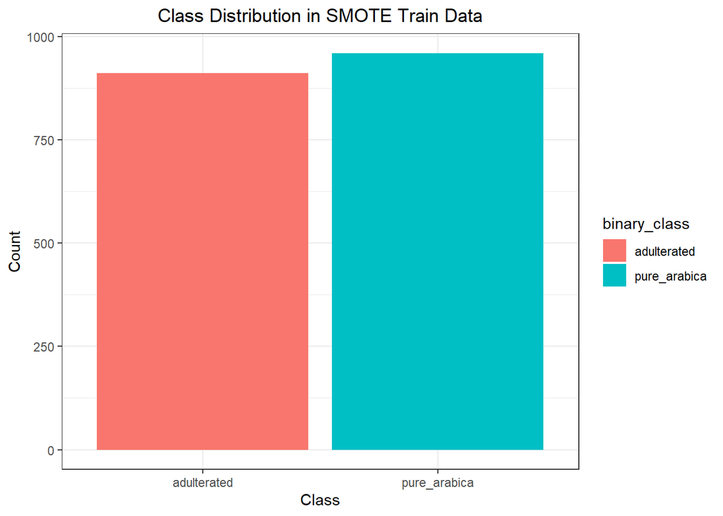

```r
# Visualize the balanced data

smote_data %>%
  count(binary_class) %>%
  ggplot(aes(x = binary_class, y = n, fill = binary_class)) +
  geom_bar(stat = "identity") +
  labs(title = "Class Distribution in SMOTE Train Data",
       x = "Class",
       y = "Count") +
  theme_bw()+
  theme(plot.title = element_text(hjust = 0.5))
```

# PreProcess by PCA, Centering and Scaling Data

```r
# Reduction dimensionality to eliminate collinearity, centering and scaling

# Imbalanced Data
pca_Preprocess<- preProcess(train_data, method = c("center", "scale", "pca"))
data_trainPreprocessed <- predict(pca_Preprocess, train_data)
data_testPreprocessed <- predict(pca_Preprocess, test_data)

#SMOTE data
pca_Preprocess_smote<- preProcess(smote_data, method = c("center", "scale", "pca"))
data_trainPreprocessed_smote <- predict(pca_Preprocess_smote, smote_data)
data_testPreprocessed_smote <- predict(pca_Preprocess_smote, test_data)
```

```r
# Check the dimensions to ensure consistency
dim(data_trainPreprocessed)
```

```
[1] 1055   10
```

```r
dim(data_testPreprocessed)
```

```
[1] 414  10
```

```r
dim(data_trainPreprocessed_smote)
```

```
[1] 1872    8
```

```r
dim(data_testPreprocessed_smote)
```

```
[1] 414   8
```

## Set Up Training Parameters

```r
# Set random seed for reproducibility

set.seed (123)

# Set up the training control(10 folds 10 times cross_validation)
control <- trainControl(method = "repeatedcv", number = 10, repeats = 10,
                        classProbs = TRUE, savePredictions = "final",
                        summaryFunction = multiClassSummary,
                        selectionFunction = 'oneSE', allowParallel = TRUE)

# OneSE rule will be used to select simplest yet optimal model within the 'best model'
```

```r
#Set the metric as accuracy
metric<-"Accuracy"
```

```r
# Detect the number of cores
num_cores <- detectCores()
# Print the number of cores
print(paste("Number of cores available:", num_cores))
```

```
[1] "Number of cores available: 8"
```

```r
# We will train all the models: kNN, NNET, SVM, LDA and RF as base learners. Then the predictions from this model will be trained by RF as a  meta-learner before testing on an external validation set.

# Hyper-parameter Tuning: We will train the model with their own set of hyper parameter settings.

# LDA model: No hyper parameter

# k-NN
grid_knn <- expand.grid(.k = seq(3,30, by = 2))

# SVM. We will use a tuneLength of 10. This will automatically select optimal Cost (C) and sigma parameter for the RBF kernel

# RF: We will also use a tuneLength of 10. This selects the optimal mtry/number of splits

# NNET model. Selects the optimal number of neurons and decay value  (regularization parameter)
grid_nnet <- expand.grid(.size=seq(1,10, by =1),.decay=c(0,0.001,0.01,0.1,0.2,0.3,0.4,0.5))
```

## Train the Models

```r
# Unmodified data

#Register cluster for caret to train the models in parallel
set.seed(123)
cl<-makeCluster(6,type = "SOCK")
suppressWarnings(suppressMessages(
  registerDoSNOW(cl)))

# Start_time
start_time<-Sys.time()

#Train the model using cross-validation (10 folds, 10 times)

# 1. Train the LDA model
fit_lda_model_snv_sg_2d <- train(binary_class ~., data = data_trainPreprocessed,
                       method = 'lda',trControl = control, metric = 'Accuracy')

# 2. Train the kNN model
fit_knn_model_snv_sg_2d <- train(binary_class ~., data = data_trainPreprocessed,
                       method = 'knn',trControl = control,
                       tuneGrid = grid_knn, metric = 'Accuracy')

# 3. Train the SVM model
fit_svm_model_snv_sg_2d <- train(binary_class ~., data = data_trainPreprocessed,
                       method = 'svmRadial',trControl = control,
                       tuneLength = 10, metric = 'Accuracy')

# 4. Train the RF model
fit_rf_model_snv_sg_2d <- train(binary_class ~., data = data_trainPreprocessed,
                       method = 'rf',trControl = control,
                       tuneLength = 10, metric = 'Accuracy')
# 5. Train the NNET model

fit_nnet_snv_sg_2d<-train(binary_class ~., data = data_trainPreprocessed,
                      method = 'nnet', tuneGrid = grid_nnet,
                      trControl = control, metric = 'Accuracy',
                      trace = FALSE, MaxNWts = 1000, maxit = 300) #unmodified data
#End_time
end_time<-Sys.time()
model_training_time<-end_time-start_time
stopCluster(cl) # Stop the parallel run cluster

print(model_training_time)
```

```
Time difference of 8.763399 mins
```

```r
# After training the models, we will stack/combine them in an ensemble

# Combine models in an ensemble

models_list = list(lda = fit_lda_model_snv_sg_2d,
                   knn = fit_knn_model_snv_sg_2d,
                   svm = fit_svm_model_snv_sg_2d,
                   rf = fit_rf_model_snv_sg_2d,
                   nnet = fit_nnet_snv_sg_2d)

# Then train using RF as a meta-learner

#Register cluster for caret to train the models in parallel
set.seed(123)
cl<-makeCluster(6,type = "SOCK")
suppressWarnings(suppressMessages(
  registerDoSNOW(cl)))

# Start_time
start_time<-Sys.time()


fit_stack_ensemble_snv_sg_2d <- caretStack(models_list, method = 'rf', metric = metric,
                                       trControl = control,tuneLength = 10)
#End_time
end_time<-Sys.time()
model_training_time<-end_time-start_time
stopCluster(cl) # Stop the parallel run cluster

print(model_training_time)
```

```
Time difference of 25.1822 secs
```

```r
# Train the models on SMOTE balanced data

#Register cluster for caret to train the models in parallel
set.seed(123)
cl<-makeCluster(6,type = "SOCK")
suppressWarnings(suppressMessages(
  registerDoSNOW(cl)))

# Start_time
start_time<-Sys.time()

#Train the model using cross-validation (10 folds, 10 times)

# 1. Train the LDA model
fit_lda_model_smote_snv_sg_2d <- train(binary_class ~.,
                                       data = data_trainPreprocessed_smote,
                                       method = 'lda',trControl = control,
                                       metric = 'Accuracy')

# 2. Train the kNN model
fit_knn_model_smote_snv_sg_2d <- train(binary_class ~.,
                                 data = data_trainPreprocessed_smote,
                                 method = 'knn',trControl = control,
                                 tuneGrid = grid_knn, metric = 'Accuracy')

# 3. Train the SVM model
fit_svm_model_smote_snv_sg_2d <- train(binary_class ~.,
                                       data = data_trainPreprocessed_smote,
                                       method = 'svmRadial',trControl = control,
                                       tuneLength = 10, metric = 'Accuracy')

# 4. Train the RF model
fit_rf_model_smote_snv_sg_2d <- train(binary_class ~.,
                                data = data_trainPreprocessed_smote,
                                method = 'rf',trControl = control,
                                tuneLength = 10, metric = 'Accuracy')
# 5. Train the NNET model

fit_nnet_smote_snv_sg_2d<-train(binary_class ~.,
                          data = data_trainPreprocessed_smote,
                          method = 'nnet', tuneGrid = grid_nnet,
                          trControl = control, metric = 'Accuracy',
                          trace = FALSE, MaxNWts = 1000, maxit = 300)
#End_time
end_time<-Sys.time()
model_training_time<-end_time-start_time
stopCluster(cl) # Stop the parallel run cluster

print(model_training_time)
```

```
Time difference of 10.98342 mins
```

```r
# Similarly, we will stack/combine them in an ensemble

# Combine models in an ensemble

models_list_smote = list(lda = fit_lda_model_smote_snv_sg_2d,
                         knn = fit_knn_model_smote_snv_sg_2d,
                         svm = fit_svm_model_smote_snv_sg_2d,
                         rf = fit_rf_model_smote_snv_sg_2d,
                         nnet = fit_nnet_smote_snv_sg_2d)

# Then train using RF as a meta-learner

#Register cluster for caret to train the models in parallel
set.seed(123)
cl<-makeCluster(6,type = "SOCK")
suppressWarnings(suppressMessages(
  registerDoSNOW(cl)))

# Start_time
start_time<-Sys.time()


fit_stack_ensemble_smote_snv_sg_2d <- caretStack(models_list_smote,
                                             method = 'rf',
                                             metric = metric,
                                             trControl = control,
                                             tuneLength = 10)
#End_time
end_time<-Sys.time()
model_training_time<-end_time-start_time
stopCluster(cl) # Stop the parallel run cluster

print(model_training_time)
```

```
Time difference of 47.41557 secs
```

```r
print(fit_stack_ensemble_snv_sg_2d) # Model on imbalanced data
```

```
The following models were ensembled: lda, knn, svm, rf, nnet

caret::train model:
Random Forest

1055 samples
   5 predictor
   2 classes: 'adulterated', 'pure_arabica'

No pre-processing
Resampling: Cross-Validated (10 fold, repeated 10 times)
Summary of sample sizes: 949, 949, 949, 950, 949, 950, ...
Resampling results across tuning parameters:

  mtry  logLoss      AUC  prAUC       Accuracy  Kappa     F1
  2     0.001746242  1    0.03722277  0.999053  0.987451  0.9995069
  3     0.001709549  1    0.04017426  0.999053  0.987451  0.9995069
  4     0.001720371  1    0.03427178  0.999053  0.987451  0.9995069
  5     0.001709533  1    0.03612228  0.999053  0.987451  0.9995069
  Sensitivity  Specificity  Pos_Pred_Value  Neg_Pred_Value  Precision  Recall
  1            0.9785       0.9990186       1               0.9990186  1
  1            0.9785       0.9990186       1               0.9990186  1
  1            0.9785       0.9990186       1               0.9990186  1
  1            0.9785       0.9990186       1               0.9990186  1
  Detection_Rate  Balanced_Accuracy
  0.9545153       0.98925
  0.9545153       0.98925
  0.9545153       0.98925
  0.9545153       0.98925

Accuracy was used to select the optimal model using  the one SE rule.
The final value used for the model was mtry = 2.

Final model:

Call:
 randomForest(x = x, y = y, mtry = param$mtry)
               Type of random forest: classification
                     Number of trees: 500
No. of variables tried at each split: 2

        OOB estimate of  error rate: 0.09%
Confusion matrix:
             adulterated pure_arabica class.error
adulterated         1007            0  0.00000000
pure_arabica           1           47  0.02083333
```

```r
print(fit_stack_ensemble_smote_snv_sg_2d) # SMOTE model
```

```
The following models were ensembled: lda, knn, svm, rf, nnet

caret::train model:
Random Forest

1872 samples
   5 predictor
   2 classes: 'adulterated', 'pure_arabica'

No pre-processing
Resampling: Cross-Validated (10 fold, repeated 10 times)
Summary of sample sizes: 1684, 1685, 1685, 1685, 1685, 1685, ...
Resampling results across tuning parameters:

  mtry  logLoss       AUC  prAUC        Accuracy   Kappa      F1
  2     0.0007787805  1    0.002637213  0.9994661  0.9989312  0.9994493
  3     0.0007680346  1    0.002851743  0.9994661  0.9989312  0.9994493
  4     0.0007423126  1    0.002478699  0.9994661  0.9989312  0.9994493
  5     0.0007494508  1    0.002473448  0.9994661  0.9989312  0.9994493
  Sensitivity  Specificity  Pos_Pred_Value  Neg_Pred_Value  Precision
  0.9989047    1            1               0.9989691       1
  0.9989047    1            1               0.9989691       1
  0.9989047    1            1               0.9989691       1
  0.9989047    1            1               0.9989691       1
  Recall     Detection_Rate  Balanced_Accuracy
  0.9989047  0.4866432       0.9994523
  0.9989047  0.4866432       0.9994523
  0.9989047  0.4866432       0.9994523
  0.9989047  0.4866432       0.9994523

Accuracy was used to select the optimal model using  the one SE rule.
The final value used for the model was mtry = 2.

Final model:

Call:
 randomForest(x = x, y = y, mtry = param$mtry)
               Type of random forest: classification
                     Number of trees: 500
No. of variables tried at each split: 2

        OOB estimate of  error rate: 0.05%
Confusion matrix:
             adulterated pure_arabica class.error
adulterated          911            1 0.001096491
pure_arabica           0          960 0.000000000
```

## Save the models for future use

```r
saveRDS(fit_stack_ensemble_snv_sg_2d,
        "fit_stack_ensemble_snv_sg_2d.rds") # for unmodified data

saveRDS(fit_stack_ensemble_smote_snv_sg_2d,
        "fit_stack_ensemble_smote_snv_sg_2d.rds") # SMOTE data
```

## Display the optimal parameters for the ensemble meta learner

```r
# Used 500 trees as a default
print(paste('The optimal parametrers for training the meta-learner rf model (on unmodified data) are mtry value of',
            fit_stack_ensemble_snv_sg_2d$ens_model$bestTune)) # unmodified data
```

```
[1] "The optimal parametrers for training the meta-learner rf model (on unmodified data) are mtry value of 2"
```

```r
print(paste('The optimal parametrers for training the meta-learner rf model (on data balanced by SMOTE) are  mtry value of', fit_stack_ensemble_smote_snv_sg_2d$ens_model$bestTune)) # unmodified data  # SMOTE data
```

```
[1] "The optimal parametrers for training the meta-learner rf model (on data balanced by SMOTE) are  mtry value of 2"
```

## Display the cross-validation results in Tables

```r
# Imbalanced data
kable(fit_stack_ensemble_snv_sg_2d$ens_model$results,
      caption = "Cross-Validation Results on Imbalanced Data") # Imbalanced Data
```

Cross-Validation Results on Imbalanced Data

| mtry | logLoss | AUC | prAUC | Accuracy | Kappa | F1 | Sensitivity | Specificity | Pos_Pred_Value | Neg_Pred_Value | Precision | Recall | Detection_Rate | Balanced_Accuracy | logLossSD | AUCSD | prAUCSD | AccuracySD | KappaSD | F1SD | SensitivitySD | SpecificitySD | Pos_Pred_ValueSD | Neg_Pred_ValueSD | PrecisionSD | RecallSD | Detection_RateSD | Balanced_AccuracySD |
| --- | --- | --- | --- | --- | --- | --- | --- | --- | --- | --- | --- | --- | --- | --- | --- | --- | --- | --- | --- | --- | --- | --- | --- | --- | --- | --- | --- | --- |
| 2 | 0.0017462 | 1 | 0.0372228 | 0.999053 | 0.987451 | 0.9995069 | 1 | 0.9785 | 0.9990186 | 1 | 0.9990186 | 1 | 0.9545153 | 0.98925 | 0.0027534 | 0 | 0.0514717 | 0.0028553 | 0.0381174 | 0.0014868 | 0 | 0.0652327 | 0.0029589 | 0 | 0.0029589 | 0 | 0.0036636 | 0.0326163 |
| 3 | 0.0017095 | 1 | 0.0401743 | 0.999053 | 0.987451 | 0.9995069 | 1 | 0.9785 | 0.9990186 | 1 | 0.9990186 | 1 | 0.9545153 | 0.98925 | 0.0027194 | 0 | 0.0583712 | 0.0028553 | 0.0381174 | 0.0014868 | 0 | 0.0652327 | 0.0029589 | 0 | 0.0029589 | 0 | 0.0036636 | 0.0326163 |
| 4 | 0.0017204 | 1 | 0.0342718 | 0.999053 | 0.987451 | 0.9995069 | 1 | 0.9785 | 0.9990186 | 1 | 0.9990186 | 1 | 0.9545153 | 0.98925 | 0.0028083 | 0 | 0.0502608 | 0.0028553 | 0.0381174 | 0.0014868 | 0 | 0.0652327 | 0.0029589 | 0 | 0.0029589 | 0 | 0.0036636 | 0.0326163 |
| 5 | 0.0017095 | 1 | 0.0361223 | 0.999053 | 0.987451 | 0.9995069 | 1 | 0.9785 | 0.9990186 | 1 | 0.9990186 | 1 | 0.9545153 | 0.98925 | 0.0027518 | 0 | 0.0531681 | 0.0028553 | 0.0381174 | 0.0014868 | 0 | 0.0652327 | 0.0029589 | 0 | 0.0029589 | 0 | 0.0036636 | 0.0326163 |

```r
# SMOTE data
kable(fit_stack_ensemble_smote_snv_sg_2d$ens_model$results,
      caption = "Cross-Validation Results on SMOTE Data") # Balanced Data
```

Cross-Validation Results on SMOTE Data

| mtry | logLoss | AUC | prAUC | Accuracy | Kappa | F1 | Sensitivity | Specificity | Pos_Pred_Value | Neg_Pred_Value | Precision | Recall | Detection_Rate | Balanced_Accuracy | logLossSD | AUCSD | prAUCSD | AccuracySD | KappaSD | F1SD | SensitivitySD | SpecificitySD | Pos_Pred_ValueSD | Neg_Pred_ValueSD | PrecisionSD | RecallSD | Detection_RateSD | Balanced_AccuracySD |
| --- | --- | --- | --- | --- | --- | --- | --- | --- | --- | --- | --- | --- | --- | --- | --- | --- | --- | --- | --- | --- | --- | --- | --- | --- | --- | --- | --- | --- |
| 2 | 0.0007788 | 1 | 0.0026372 | 0.9994661 | 0.9989312 | 0.9994493 | 0.9989047 | 1 | 1 | 0.9989691 | 1 | 0.9989047 | 0.4866432 | 0.9994523 | 0.0023135 | 0 | 0.0047310 | 0.0016098 | 0.0032225 | 0.0016604 | 0.0033026 | 0 | 0 | 0.0031084 | 0 | 0.0033026 | 0.0018722 | 0.0016513 |
| 3 | 0.0007680 | 1 | 0.0028517 | 0.9994661 | 0.9989312 | 0.9994493 | 0.9989047 | 1 | 1 | 0.9989691 | 1 | 0.9989047 | 0.4866432 | 0.9994523 | 0.0022800 | 0 | 0.0044018 | 0.0016098 | 0.0032225 | 0.0016604 | 0.0033026 | 0 | 0 | 0.0031084 | 0 | 0.0033026 | 0.0018722 | 0.0016513 |
| 4 | 0.0007423 | 1 | 0.0024787 | 0.9994661 | 0.9989312 | 0.9994493 | 0.9989047 | 1 | 1 | 0.9989691 | 1 | 0.9989047 | 0.4866432 | 0.9994523 | 0.0022108 | 0 | 0.0046009 | 0.0016098 | 0.0032225 | 0.0016604 | 0.0033026 | 0 | 0 | 0.0031084 | 0 | 0.0033026 | 0.0018722 | 0.0016513 |
| 5 | 0.0007495 | 1 | 0.0024734 | 0.9994661 | 0.9989312 | 0.9994493 | 0.9989047 | 1 | 1 | 0.9989691 | 1 | 0.9989047 | 0.4866432 | 0.9994523 | 0.0022309 | 0 | 0.0043946 | 0.0016098 | 0.0032225 | 0.0016604 | 0.0033026 | 0 | 0 | 0.0031084 | 0 | 0.0033026 | 0.0018722 | 0.0016513 |

```r
# Select the best results row for unmodified data
selected_row <- fit_stack_ensemble_snv_sg_2d$ens_model$results %>%
  filter(mtry == fit_stack_ensemble_snv_sg_2d$ens_model$bestTune$mtry)

kable(selected_row)
```

| mtry | logLoss | AUC | prAUC | Accuracy | Kappa | F1 | Sensitivity | Specificity | Pos_Pred_Value | Neg_Pred_Value | Precision | Recall | Detection_Rate | Balanced_Accuracy | logLossSD | AUCSD | prAUCSD | AccuracySD | KappaSD | F1SD | SensitivitySD | SpecificitySD | Pos_Pred_ValueSD | Neg_Pred_ValueSD | PrecisionSD | RecallSD | Detection_RateSD | Balanced_AccuracySD |
| --- | --- | --- | --- | --- | --- | --- | --- | --- | --- | --- | --- | --- | --- | --- | --- | --- | --- | --- | --- | --- | --- | --- | --- | --- | --- | --- | --- | --- |
| 2 | 0.0017462 | 1 | 0.0372228 | 0.999053 | 0.987451 | 0.9995069 | 1 | 0.9785 | 0.9990186 | 1 | 0.9990186 | 1 | 0.9545153 | 0.98925 | 0.0027534 | 0 | 0.0514717 | 0.0028553 | 0.0381174 | 0.0014868 | 0 | 0.0652327 | 0.0029589 | 0 | 0.0029589 | 0 | 0.0036636 | 0.0326163 |

```r
# Select the best results row for SMOTE Data
selected_row <- fit_stack_ensemble_smote_snv_sg_2d$ens_model$results %>%
  filter(mtry == fit_stack_ensemble_smote_snv_sg_2d$ens_model$bestTune$mtry)

kable(selected_row)
```

| mtry | logLoss | AUC | prAUC | Accuracy | Kappa | F1 | Sensitivity | Specificity | Pos_Pred_Value | Neg_Pred_Value | Precision | Recall | Detection_Rate | Balanced_Accuracy | logLossSD | AUCSD | prAUCSD | AccuracySD | KappaSD | F1SD | SensitivitySD | SpecificitySD | Pos_Pred_ValueSD | Neg_Pred_ValueSD | PrecisionSD | RecallSD | Detection_RateSD | Balanced_AccuracySD |
| --- | --- | --- | --- | --- | --- | --- | --- | --- | --- | --- | --- | --- | --- | --- | --- | --- | --- | --- | --- | --- | --- | --- | --- | --- | --- | --- | --- | --- |
| 2 | 0.0007788 | 1 | 0.0026372 | 0.9994661 | 0.9989312 | 0.9994493 | 0.9989047 | 1 | 1 | 0.9989691 | 1 | 0.9989047 | 0.4866432 | 0.9994523 | 0.0023135 | 0 | 0.004731 | 0.0016098 | 0.0032225 | 0.0016604 | 0.0033026 | 0 | 0 | 0.0031084 | 0 | 0.0033026 | 0.0018722 | 0.0016513 |

## Confusion matrix for the training data

```r
confusionMatrix(fit_stack_ensemble_snv_sg_2d$ens_model$pred$pred,
                fit_stack_ensemble_snv_sg_2d$ens_model$pred$obs) # unmodified data
```

```
Confusion Matrix and Statistics

              Reference
Prediction     adulterated pure_arabica
  adulterated        10070           10
  pure_arabica           0          470

               Accuracy : 0.9991
                 95% CI : (0.9983, 0.9995)
    No Information Rate : 0.9545
    P-Value [Acc > NIR] : < 2.2e-16

                  Kappa : 0.989

 Mcnemar's Test P-Value : 0.004427

            Sensitivity : 1.0000
            Specificity : 0.9792
         Pos Pred Value : 0.9990
         Neg Pred Value : 1.0000
             Prevalence : 0.9545
         Detection Rate : 0.9545
   Detection Prevalence : 0.9555
      Balanced Accuracy : 0.9896

       'Positive' Class : adulterated
```

```r
confusionMatrix(fit_stack_ensemble_smote_snv_sg_2d$ens_model$pred$pred,
                fit_stack_ensemble_smote_snv_sg_2d$ens_model$pred$obs) # SMOTE data
```

```
Confusion Matrix and Statistics

              Reference
Prediction     adulterated pure_arabica
  adulterated         9110            0
  pure_arabica          10         9600

               Accuracy : 0.9995
                 95% CI : (0.999, 0.9997)
    No Information Rate : 0.5128
    P-Value [Acc > NIR] : < 2.2e-16

                  Kappa : 0.9989

 Mcnemar's Test P-Value : 0.004427

            Sensitivity : 0.9989
            Specificity : 1.0000
         Pos Pred Value : 1.0000
         Neg Pred Value : 0.9990
             Prevalence : 0.4872
         Detection Rate : 0.4866
   Detection Prevalence : 0.4866
      Balanced Accuracy : 0.9995

       'Positive' Class : adulterated
```

Visualize Hyperparameter Tuning for Optimal Model Selection

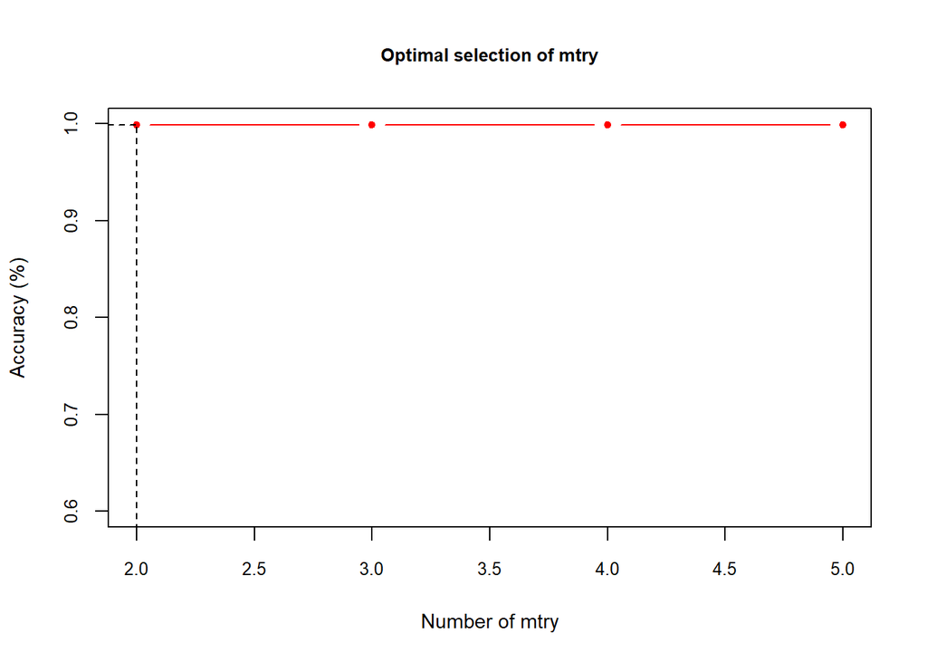

```r
# Imbalanced Data

mtry_data <- fit_stack_ensemble_snv_sg_2d$ens_model$results
best_mtry = fit_stack_ensemble_snv_sg_2d$ens_model$bestTune$mtry
y_Acc = mtry_data$Accuracy[mtry_data$mtry == best_mtry]

#Plot the CV results

plot(mtry_data$mtry,mtry_data$Accuracy,
     type = "b",col = "red",pch = 20,cex.axis = 0.8,
     ylim = c(0.6, 1),
     xlab = "Number of mtry",
     ylab = "Accuracy (%)",cex.lab = 0.9, main = 'Optimal selection of mtry',
     cex.main = 0.8)
# Add line from x-axis to the specific point
segments(x0 = best_mtry, y0 = 0, x1 = best_mtry, y1 = y_Acc, col = "black", lty = 2)

# Add line from y-axis to the specific point
segments(x0 = 0, y0 = y_Acc, x1 = best_mtry, y1 = y_Acc, col = "black", lty = 2)
```

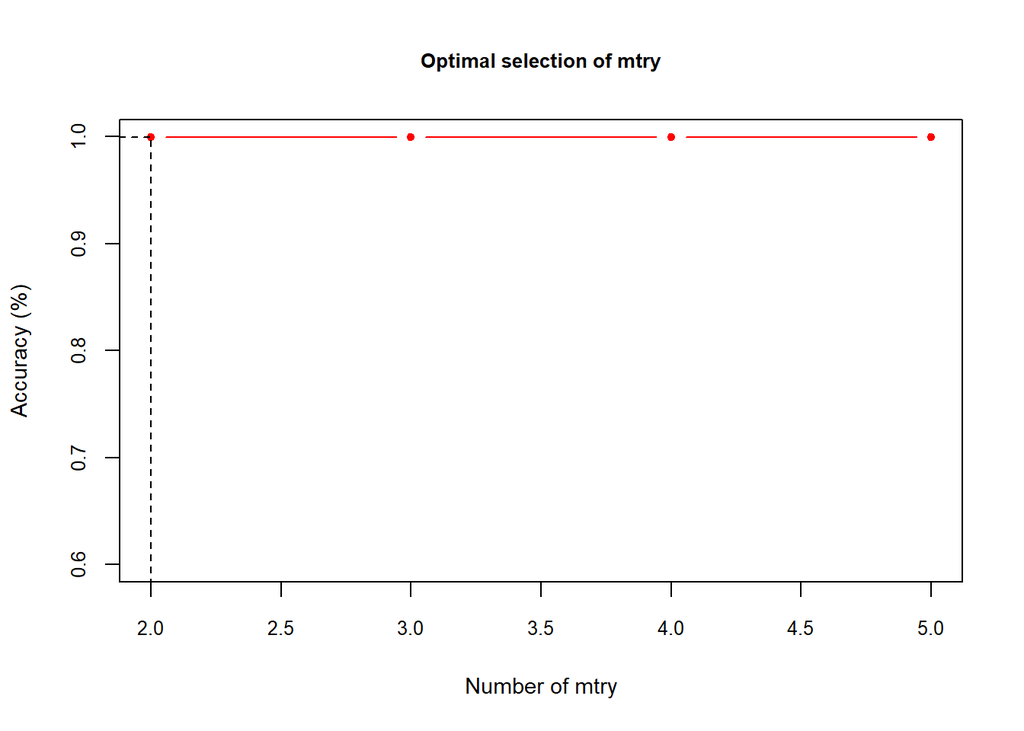

```r
# SMOTE Data

mtry_data <- fit_stack_ensemble_smote_snv_sg_2d$ens_model$results
best_mtry = fit_stack_ensemble_smote_snv_sg_2d$ens_model$bestTune$mtry
y_Acc = mtry_data$Accuracy[mtry_data$mtry == best_mtry]

#Plot the CV results

plot(mtry_data$mtry,mtry_data$Accuracy,
     type = "b",col = "red",pch = 20,cex.axis = 0.8,
     ylim = c(0.6, 1),
     xlab = "Number of mtry",
     ylab = "Accuracy (%)",cex.lab = 0.9, main = 'Optimal selection of mtry',
     cex.main = 0.8)
# Add line from x-axis to the specific point
segments(x0 = best_mtry, y0 = 0, x1 = best_mtry, y1 = y_Acc, col = "black", lty = 2)

# Add line from y-axis to the specific point
segments(x0 = 0, y0 = y_Acc, x1 = best_mtry, y1 = y_Acc, col = "black", lty = 2)
```

## Visualize the Out of Bag Errors (OOB)

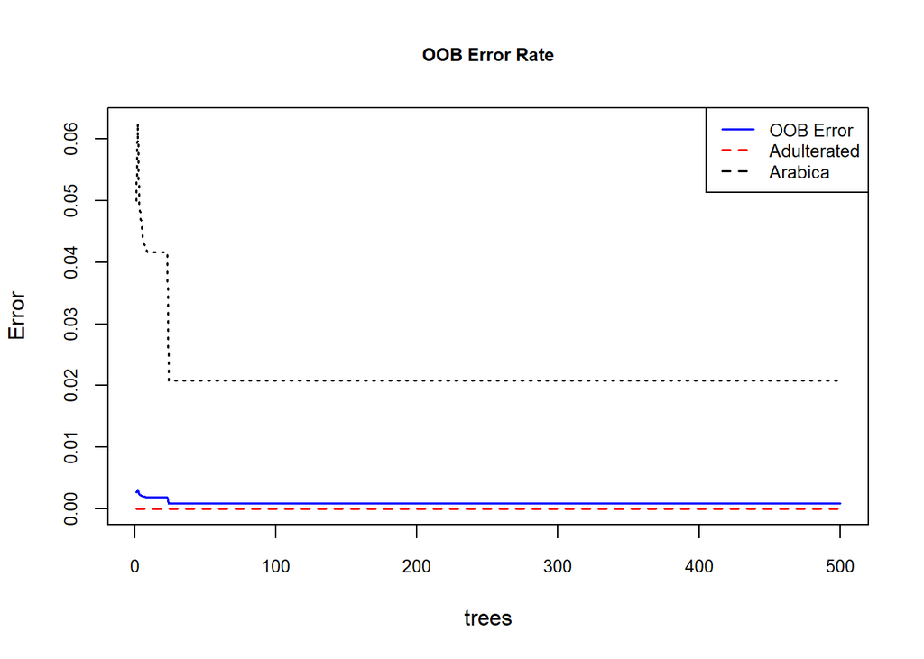

```r
# Unmodified data

# Plot the OOB error from the ensemble model
plot(fit_stack_ensemble_snv_sg_2d$ens_model$finalModel,
     main = 'OOB Error Rate',
     cex.main = 0.8,
     cex.axis = 0.8,
     col = c('blue', 'red', 'black'),
     lwd = 1.5)

# Add legend
legend("topright",
       legend = c("OOB Error", "Adulterated", "Arabica"),
       col = c('blue', 'red', 'black'),
       lty = c(1,2,2),
       lwd = 1.5,
       cex = 0.8)
```

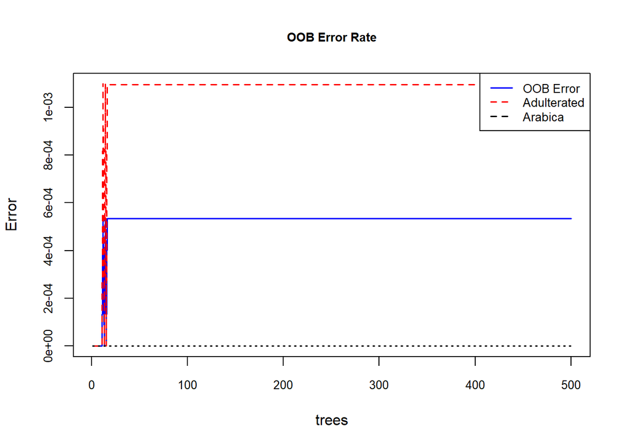

```r
# SMOTE Data

# Plot the OOB error from the ensemble model
plot(fit_stack_ensemble_smote_snv_sg_2d$ens_model$finalModel,
     main = 'OOB Error Rate',
     cex.main = 0.8,
     cex.axis = 0.8,
     col = c('blue', 'red', 'black'),
     lwd = 1.5)

# Add legend
legend("topright",
       legend = c("OOB Error", "Adulterated", "Arabica"),
       col = c('blue', 'red', 'black'),
       lty = c(1,2,2),
       lwd = 1.5,
       cex = 0.8)
```

## Test the model peformance on test data for unbalanced trained data

```r
# Make predictions with the ensemble model: Imbalanced Data

test_ensemble_unmodified <- predict(fit_stack_ensemble_snv_sg_2d,
                                newdata=data_testPreprocessed)

# Apply threshold to probabilities
class_predictions_unmodified <- ifelse(test_ensemble_unmodified[, "adulterated"] >= 0.5,
                             "adulterated",
                             "pure_arabica")

# Convert to a factor
class_predictions_unmodified <- factor(class_predictions_unmodified,
                                       levels = c("adulterated", "pure_arabica"))

reference_unmodified <- data_testPreprocessed$binary_class

# Get the confusion matrix

test_ensemble_unmodified_cfmatrix <- confusionMatrix(class_predictions_unmodified,
                                          reference_unmodified)
test_ensemble_unmodified_cfmatrix
```

```
Confusion Matrix and Statistics

              Reference
Prediction     adulterated pure_arabica
  adulterated          385            0
  pure_arabica           2           27

               Accuracy : 0.9952
                 95% CI : (0.9827, 0.9994)
    No Information Rate : 0.9348
    P-Value [Acc > NIR] : 3.338e-10

                  Kappa : 0.9617

 Mcnemar's Test P-Value : 0.4795

            Sensitivity : 0.9948
            Specificity : 1.0000
         Pos Pred Value : 1.0000
         Neg Pred Value : 0.9310
             Prevalence : 0.9348
         Detection Rate : 0.9300
   Detection Prevalence : 0.9300
      Balanced Accuracy : 0.9974

       'Positive' Class : adulterated
```

```r
# View the results as knitr table
kable(test_ensemble_unmodified_cfmatrix$byClass)
```

|  | x |
| --- | --- |
| Sensitivity | 0.9948320 |
| Specificity | 1.0000000 |
| Pos Pred Value | 1.0000000 |
| Neg Pred Value | 0.9310345 |
| Precision | 1.0000000 |
| Recall | 0.9948320 |
| F1 | 0.9974093 |
| Prevalence | 0.9347826 |
| Detection Rate | 0.9299517 |
| Detection Prevalence | 0.9299517 |
| Balanced Accuracy | 0.9974160 |

```r
# View the results as knitr table
kable(test_ensemble_unmodified_cfmatrix$table)
```

|  | adulterated | pure_arabica |
| --- | --- | --- |
| adulterated | 385 | 0 |
| pure_arabica | 2 | 27 |

```r
# Extracting the components of the confusion matrix
cf_table_nnet <- test_ensemble_unmodified_cfmatrix$table
TP <- cf_table_nnet[1,1]
TN <- cf_table_nnet[2,2]
FP <- cf_table_nnet[2,1]
FN <- cf_table_nnet[1,2]

# Calculating MCC
MCC <- (TP * TN - FP * FN) / sqrt((TP + FP) * (TP + FN) * (TN + FP) * (TN + FN))

# Printing the MCC value
print(paste("The MCC value is for the model",MCC))
```

```
[1] "The MCC value is for the model 0.962404766740121"
```

## Test the model performance on test data using SMOTE trained model

```r
# Make predictions with the ensemble model: SMOTE Data

test_ensemble_smote <- predict(fit_stack_ensemble_smote_snv_sg_2d,
                                newdata=data_testPreprocessed_smote)

# Apply threshold to probabilities
class_predictions_smote <- ifelse(test_ensemble_smote[, "adulterated"] >= 0.5,
                             "adulterated",
                             "pure_arabica")

# Convert to a factor
class_predictions_smote <- factor(class_predictions_smote,
                                       levels = c("adulterated", "pure_arabica"))

reference_smote <- data_testPreprocessed_smote$binary_class

# Get the confusion matrix

test_ensemble_smote_cfmatrix <- confusionMatrix(class_predictions_smote,
                                          reference_smote)
test_ensemble_smote_cfmatrix
```

```
Confusion Matrix and Statistics

              Reference
Prediction     adulterated pure_arabica
  adulterated          387            3
  pure_arabica           0           24

               Accuracy : 0.9928
                 95% CI : (0.979, 0.9985)
    No Information Rate : 0.9348
    P-Value [Acc > NIR] : 3.318e-09

                  Kappa : 0.9373

 Mcnemar's Test P-Value : 0.2482

            Sensitivity : 1.0000
            Specificity : 0.8889
         Pos Pred Value : 0.9923
         Neg Pred Value : 1.0000
             Prevalence : 0.9348
         Detection Rate : 0.9348
   Detection Prevalence : 0.9420
      Balanced Accuracy : 0.9444

       'Positive' Class : adulterated
```

```r
# View the results as knitr table
kable(test_ensemble_smote_cfmatrix$byClass)
```

|  | x |
| --- | --- |
| Sensitivity | 1.0000000 |
| Specificity | 0.8888889 |
| Pos Pred Value | 0.9923077 |
| Neg Pred Value | 1.0000000 |
| Precision | 0.9923077 |
| Recall | 1.0000000 |
| F1 | 0.9961390 |
| Prevalence | 0.9347826 |
| Detection Rate | 0.9347826 |
| Detection Prevalence | 0.9420290 |
| Balanced Accuracy | 0.9444444 |

```r
# View the results as knitr table
kable(test_ensemble_smote_cfmatrix$table)
```

|  | adulterated | pure_arabica |
| --- | --- | --- |
| adulterated | 387 | 3 |
| pure_arabica | 0 | 24 |

```r
# Extracting the components of the confusion matrix
cf_table_nnet <- test_ensemble_smote_cfmatrix$table
TP <- cf_table_nnet[1,1]
TN <- cf_table_nnet[2,2]
FP <- cf_table_nnet[2,1]
FN <- cf_table_nnet[1,2]

# Calculating MCC
MCC <- (TP * TN - FP * FN) / sqrt((TP + FP) * (TP + FN) * (TN + FP) * (TN + FN))

# Printing the MCC value
print(paste("The MCC value is for the model",MCC))
```

```
[1] "The MCC value is for the model 0.93917585257037"
```

## Compare the models for unbalanced and balanced data

```r
library(knitr)
# Compare model performance
results <- resamples(list(ensemble_1 = fit_stack_ensemble_snv_sg_2d$ens_model,
                          ensemble_smote = fit_stack_ensemble_smote_snv_sg_2d$ens_model))

# Print summary of re-sampling results
resample_summary <- summary(results)$statistics

# Convert re-sampling statistics to a data frame
resample_df <- do.call(rbind, lapply(resample_summary, function(x) x[, "Mean", drop = FALSE]))

# Create a neat table
kable(resample_df, caption = "Model Performance Metrics")
```

Model Performance Metrics

|  | Mean |
| --- | --- |
| ensemble_1 | 0.9990530 |
| ensemble_smote | 0.9994661 |
| ensemble_1 | 1.0000000 |
| ensemble_smote | 1.0000000 |
| ensemble_1 | 0.9892500 |
| ensemble_smote | 0.9994523 |
| ensemble_1 | 0.9545153 |
| ensemble_smote | 0.4866432 |
| ensemble_1 | 0.9995069 |
| ensemble_smote | 0.9994493 |
| ensemble_1 | 0.9874510 |
| ensemble_smote | 0.9989312 |
| ensemble_1 | 0.0017462 |
| ensemble_smote | 0.0007788 |
| ensemble_1 | 1.0000000 |
| ensemble_smote | 0.9989691 |
| ensemble_1 | 0.9990186 |
| ensemble_smote | 1.0000000 |
| ensemble_1 | 0.0372228 |
| ensemble_smote | 0.0026372 |
| ensemble_1 | 0.9990186 |
| ensemble_smote | 1.0000000 |
| ensemble_1 | 1.0000000 |
| ensemble_smote | 0.9989047 |
| ensemble_1 | 1.0000000 |
| ensemble_smote | 0.9989047 |
| ensemble_1 | 0.9785000 |
| ensemble_smote | 1.0000000 |

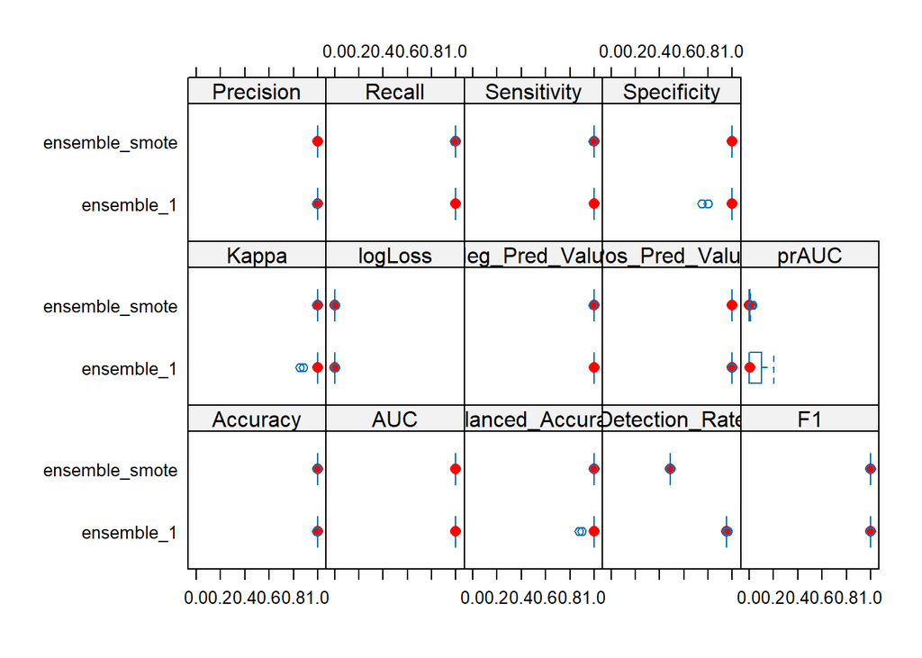

```r
# Boxplot for accuracy comparison
bwplot(results, col = 'red')
```

```r
# Pairwise comparisons
model_differences <- diff(results)
model_differences$statistics
```

```
$Accuracy
$Accuracy$ensemble_1.diff.ensemble_smote

    One Sample t-test

data:  x
t = -1.2601, df = 99, p-value = 0.2106
alternative hypothesis: true mean is not equal to 0
95 percent confidence interval:
 -0.0010635477  0.0002373795
sample estimates:
    mean of x
-0.0004130841



$AUC
$AUC$ensemble_1.diff.ensemble_smote

    One Sample t-test

data:  x
t = NaN, df = 99, p-value = NA
alternative hypothesis: true mean is not equal to 0
95 percent confidence interval:
 NaN NaN
sample estimates:
mean of x
        0



$Balanced_Accuracy
$Balanced_Accuracy$ensemble_1.diff.ensemble_smote

    One Sample t-test

data:  x
t = -3.1228, df = 99, p-value = 0.002349
alternative hypothesis: true mean is not equal to 0
```

[output cut: 166 more lines]

```


$Specificity
$Specificity$ensemble_1.diff.ensemble_smote

    One Sample t-test

data:  x
t = -3.2959, df = 99, p-value = 0.001363
alternative hypothesis: true mean is not equal to 0
95 percent confidence interval:
 -0.03444358 -0.00855642
sample estimates:
mean of x
  -0.0215
```

## Visualize the confusion matrix tables

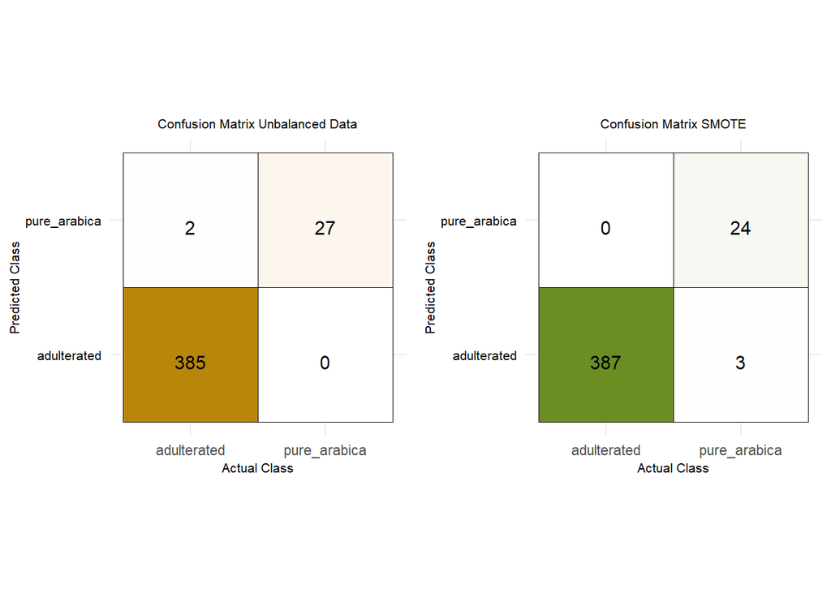

```r
p1<-ggplot(data = as.data.frame(test_ensemble_unmodified_cfmatrix$table), aes(x = Reference, y = Prediction)) +
  geom_tile(aes(fill = Freq), color = "black") +
  geom_text(aes(label = sprintf("%0.0f", Freq)), vjust = 1,color = "black",size = 4) +
  scale_fill_gradient(low = "white", high = "darkgoldenrod", name = "Frequency") +
  theme_minimal() +
  labs(x = "Actual Class", y = "Predicted Class", color = 'black',title = 'Confusion Matrix Unbalanced Data')+
  theme(
    legend.position =  "none",
    axis.text.y = element_text(color = "black",size = 8),
    axis.title.x  = element_text(size = 8),
    axis.title.y = element_text(size = 8),aspect.ratio = 1,
    plot.title = element_text(size = 8,hjust = 0.5))


p2<-ggplot(data = as.data.frame(test_ensemble_smote_cfmatrix$table), aes(x = Reference, y = Prediction)) +
  geom_tile(aes(fill = Freq), color = "black") +
  geom_text(aes(label = sprintf("%0.0f", Freq)), vjust = 1,color = "black",size = 4) +
  scale_fill_gradient(low = "white", high = "olivedrab", name = "Frequency") +
  theme_minimal() +
  labs(x = "Actual Class", y = "Predicted Class", color = 'black',title = 'Confusion Matrix SMOTE')+
  theme(
    legend.position =  "none",
    axis.text.y = element_text(color = "black",size = 8),
    axis.title.x  = element_text(size = 8),
    axis.title.y = element_text(size = 8),aspect.ratio = 1,
    plot.title = element_text(size = 8,hjust = 0.5))

grid.arrange(p1,p2, nrow =1)
```

## ROC Curve

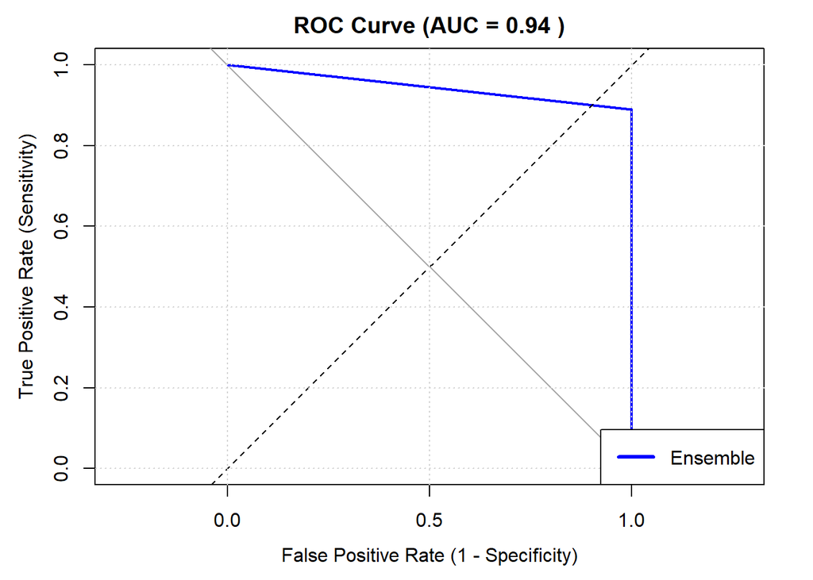

```r
# Generate the ROC curve
roc_curve <- roc(data_testPreprocessed$binary_class,
                 as.numeric(class_predictions_smote),
                 levels = c("adulterated", "pure_arabica"),
                 positive = 'adulterated')
# Calculate the AUC
auc_value <- auc(roc_curve)

# Plot the ROC curve
plot(roc_curve, col = 'blue', lwd = 2,
     main = paste("ROC Curve (AUC =", round(auc_value, 2), ")"),
     xlab = "False Positive Rate (1 - Specificity)",
     ylab = "True Positive Rate (Sensitivity)",
     xlim = c(0, 1), ylim = c(0, 1))
abline(a = 0, b = 1, lty = 2, col = "black")
grid(nx = NULL, ny = NULL, col = "lightgray", lty = "dotted")
legend("bottomright", legend = c("Ensemble"), col = 'blue', lwd = 3)
```

## Conclusion

- The ensemble stacked models demonstrate exceptional performance in classifying authentic and adulterated coffee samples. The technique achieves a Matthews Correlation Coefficient (MCC) value as high as 0.9, underscoring its robustness and reliability in distinguishing between pure Arabica and adulterated coffee with high accuracy and balanced predictions.